# Food and You analyses_enviroment impact 27112023

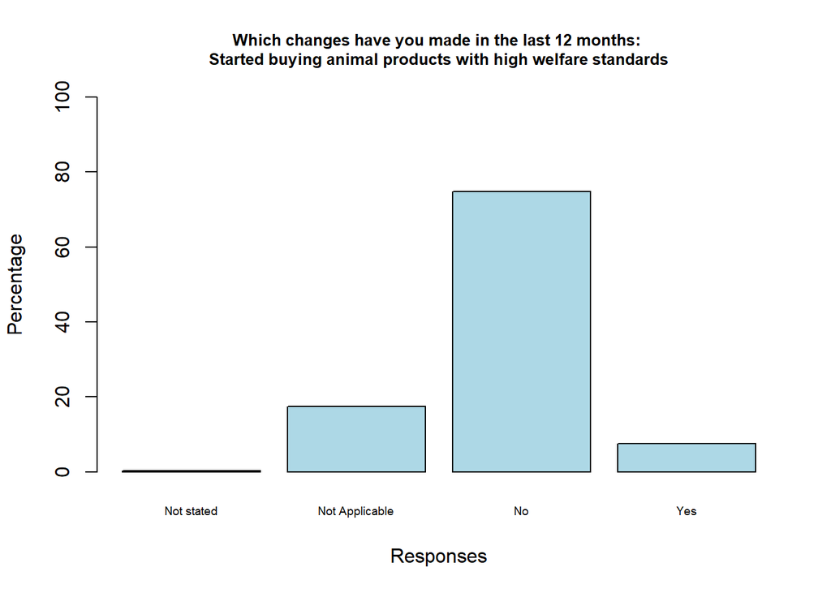

```r
barplot(table(Wave_4$susbehv8)/length(Wave_4$susbehv8) * 100,
        main = "Which changes have you made in the last 12 months: \nStarted buying animal products with high welfare standards",
        xlab = "Responses",
        ylab = "Percentage",
        ylim = c(0, 100),
        names.arg = c("Not stated", "Not Applicable", "No", "Yes"), #if yes, go to g51
        col = "lightblue",
        cex.main=0.8,
        cex.names=0.6)
```

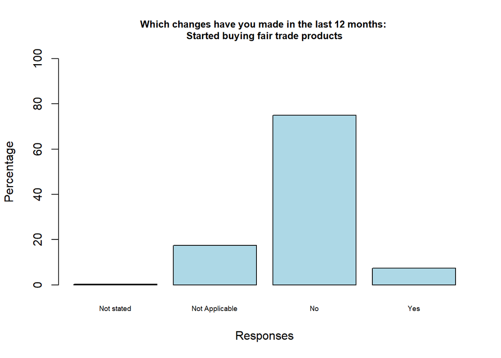

```r
barplot(table(Wave_4$susbehv9)/length(Wave_4$susbehv9) * 100,
        main = "Which changes have you made in the last 12 months: \nStarted buying fair trade products",
        xlab = "Responses",
        ylab = "Percentage",
        ylim = c(0, 100),
        names.arg = c("Not stated", "Not Applicable", "No", "Yes"), #if yes, go to g51
        col = "lightblue",
        cex.main=0.8,
        cex.names=0.6)
```

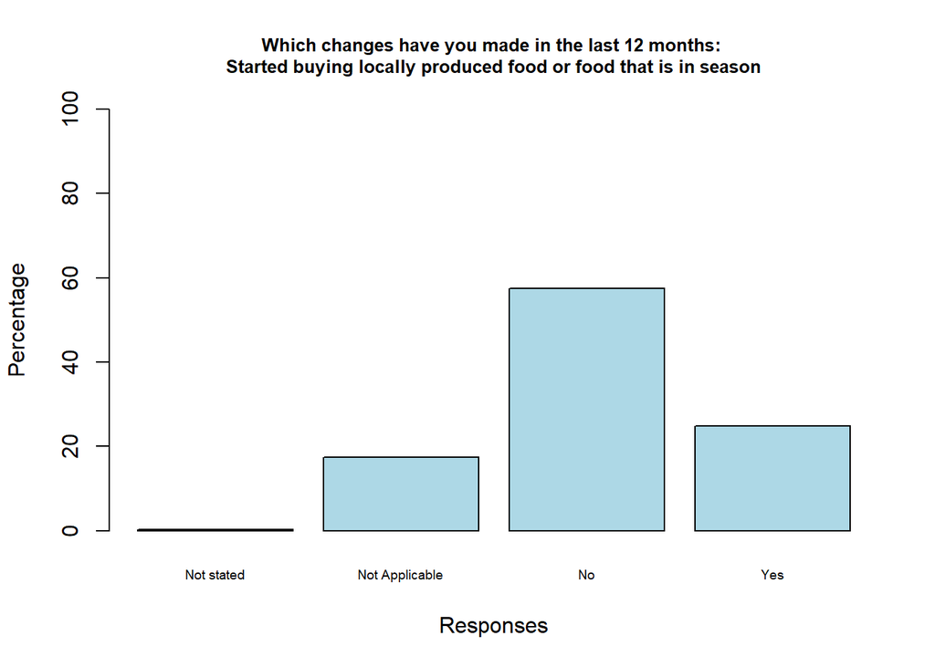

```r
barplot(table(Wave_4$susbehv10)/length(Wave_4$susbehv10) * 100,
        main = "Which changes have you made in the last 12 months: \nStarted buying locally produced food or food that is in season",
        xlab = "Responses",
        ylab = "Percentage",
        ylim = c(0, 100),
        names.arg = c("Not stated", "Not Applicable", "No", "Yes"), #if yes, go to g51
        col = "lightblue",
        cex.main=0.8,
        cex.names=0.6)
```

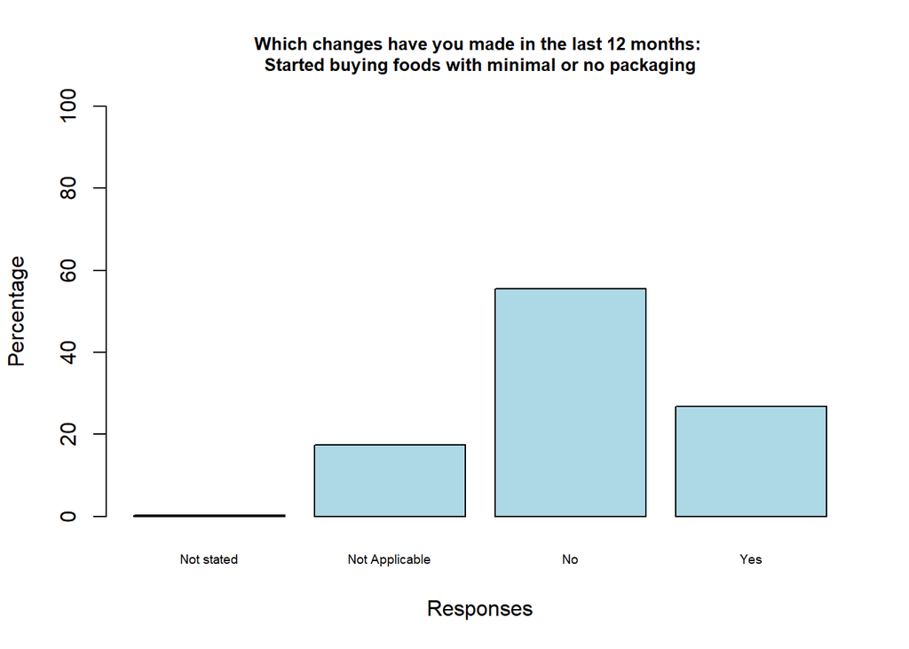

```r
barplot(table(Wave_4$susbehv11)/length(Wave_4$susbehv11) * 100,
        main = "Which changes have you made in the last 12 months: \nStarted buying foods with minimal or no packaging",
        xlab = "Responses",
        ylab = "Percentage",
        ylim = c(0, 100),
        names.arg = c("Not stated", "Not Applicable", "No", "Yes"), #if yes, go to g51
        col = "lightblue",
        cex.main=0.8,
        cex.names=0.6)
```

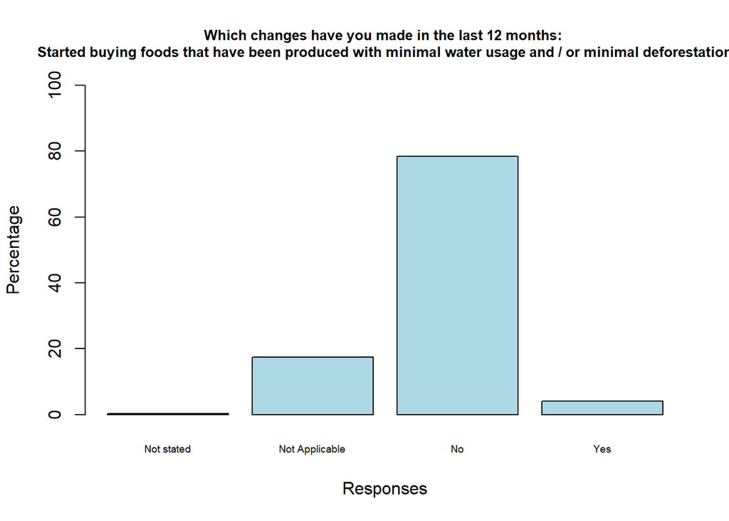

```r
barplot(table(Wave_4$susbehv12)/length(Wave_4$susbehv12) * 100,
        main = "Which changes have you made in the last 12 months: \nStarted buying foods that have been produced with minimal water usage and / or minimal deforestation",
        xlab = "Responses",
        ylab = "Percentage",
        ylim = c(0, 100),
        names.arg = c("Not stated", "Not Applicable", "No", "Yes"), #if yes, go to g51
        col = "lightblue",
        cex.main=0.8,
        cex.names=0.6)
```

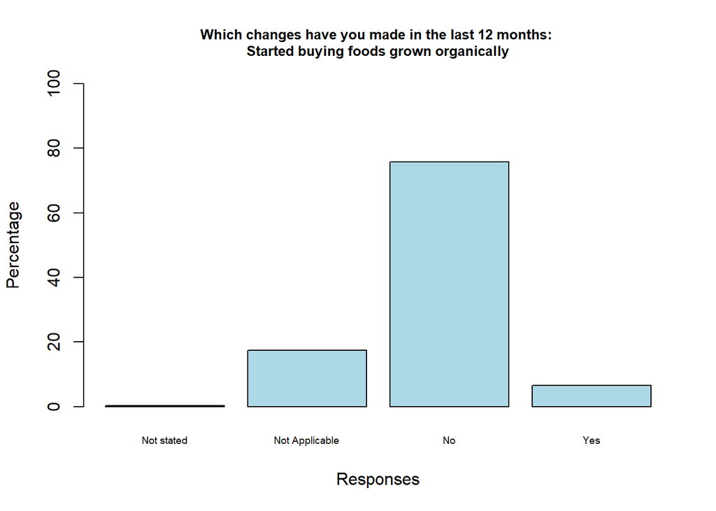

```r
barplot(table(Wave_4$susbehv13)/length(Wave_4$susbehv13) * 100,
        main = "Which changes have you made in the last 12 months: \nStarted buying foods grown organically",
        xlab = "Responses",
        ylab = "Percentage",
        ylim = c(0, 100),
        names.arg = c("Not stated", "Not Applicable", "No", "Yes"), #if yes, go to g51
        col = "lightblue",
        cex.main=0.8,
        cex.names=0.6)
```

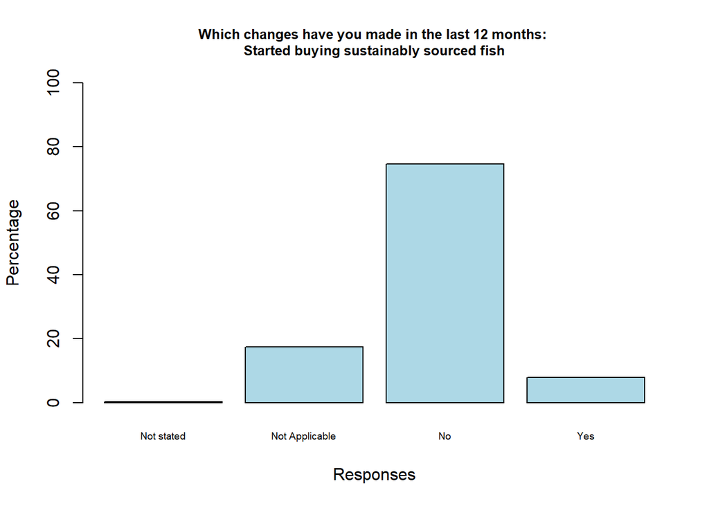

```r
barplot(table(Wave_4$susbehv14)/length(Wave_4$susbehv14) * 100,
        main = "Which changes have you made in the last 12 months: \nStarted buying sustainably sourced fish",
        xlab = "Responses",
        ylab = "Percentage",
        ylim = c(0, 100),
        names.arg = c("Not stated", "Not Applicable", "No", "Yes"), #if yes, go to g51
        col = "lightblue",
        cex.main=0.8,
        cex.names=0.6)
```

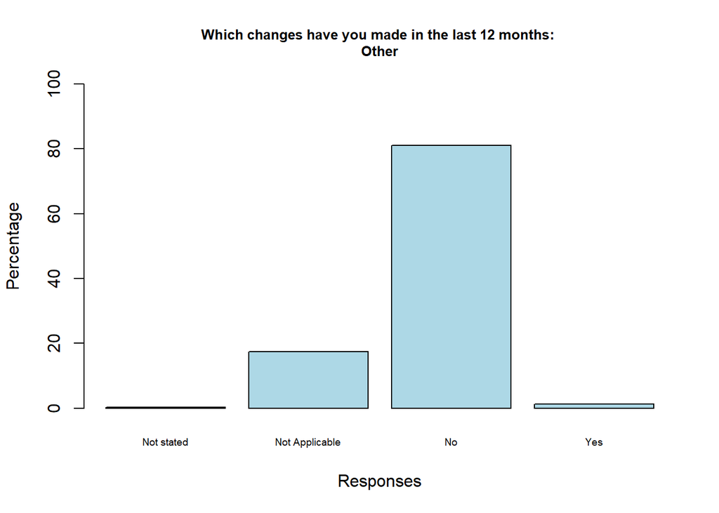

```r
barplot(table(Wave_4$susbehv15)/length(Wave_4$susbehv15) * 100,
        main = "Which changes have you made in the last 12 months: \nOther",
        xlab = "Responses",
        ylab = "Percentage",
        ylim = c(0, 100),
        names.arg = c("Not stated", "Not Applicable", "No", "Yes"), #if yes, go to g51
        col = "lightblue",
        cex.main=0.8,
        cex.names=0.6)
```

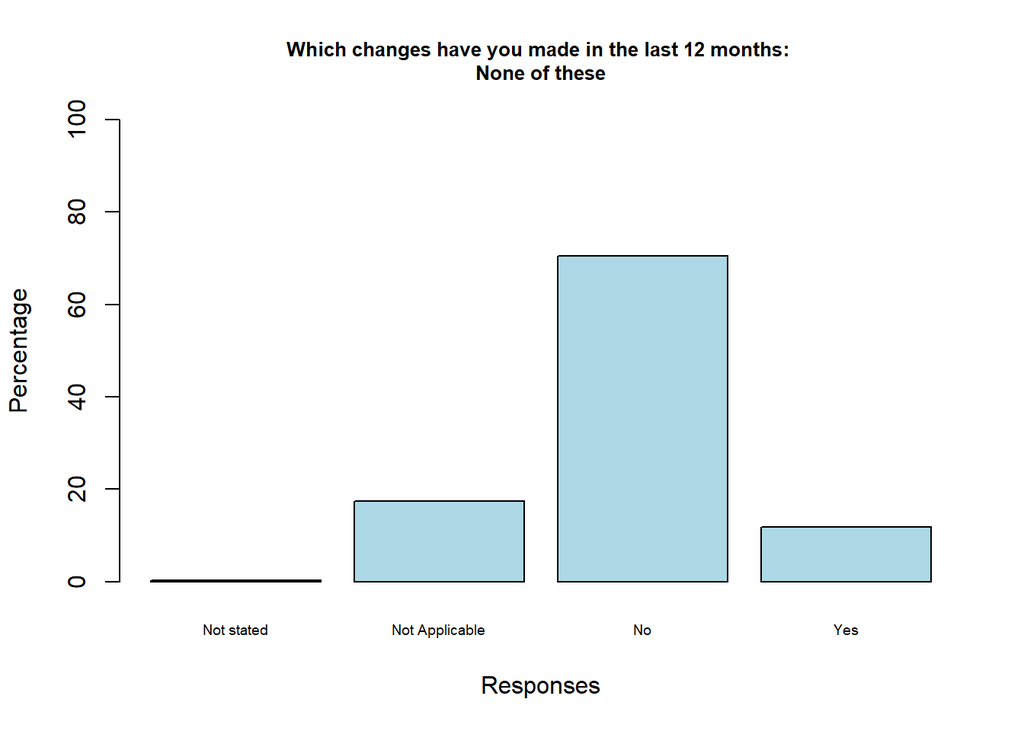

```r
barplot(table(Wave_4$susbehv16)/length(Wave_4$susbehv16) * 100,
        main = "Which changes have you made in the last 12 months: \nNone of these",
        xlab = "Responses",
        ylab = "Percentage",
        ylim = c(0, 100),
        names.arg = c("Not stated", "Not Applicable", "No", "Yes"), #if yes, go to g51
        col = "lightblue",
        cex.main=0.8,
        cex.names=0.6)
```

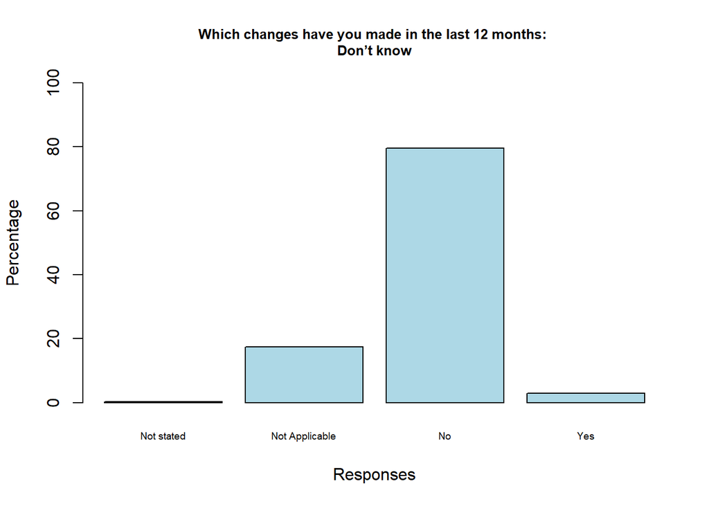

```r
barplot(table(Wave_4$susbehv17)/length(Wave_4$susbehv17) * 100,
        main = "Which changes have you made in the last 12 months: \nDon’t know",
        xlab = "Responses",
        ylab = "Percentage",
        ylim = c(0, 100),
        names.arg = c("Not stated", "Not Applicable", "No", "Yes"), #if yes, go to g51
        col = "lightblue",
        cex.main=0.8,
        cex.names=0.6)
```

## What types of meat, poultry and/or fish have you stopped eating in the last 12 months

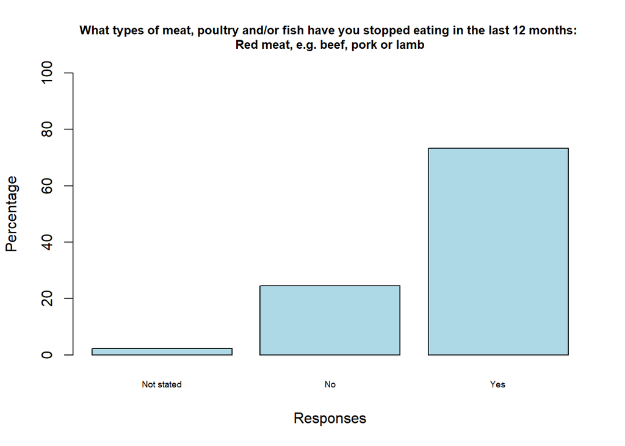

```r
yes_subsetQ48 <- subset(Wave_4, susbehv1 == 1) #90obs

barplot(table(yes_subsetQ48$stopmpf1)/length(yes_subsetQ48$stopmpf1) * 100,
        main = "What types of meat, poultry and/or fish have you stopped eating in the last 12 months: \nRed meat, e.g. beef, pork or lamb",
        xlab = "Responses",
        ylab = "Percentage",
        ylim = c(0, 100),
        names.arg = c("Not stated", "No", "Yes"),
        col = "lightblue",
        cex.main=0.8,
        cex.names=0.6)
```

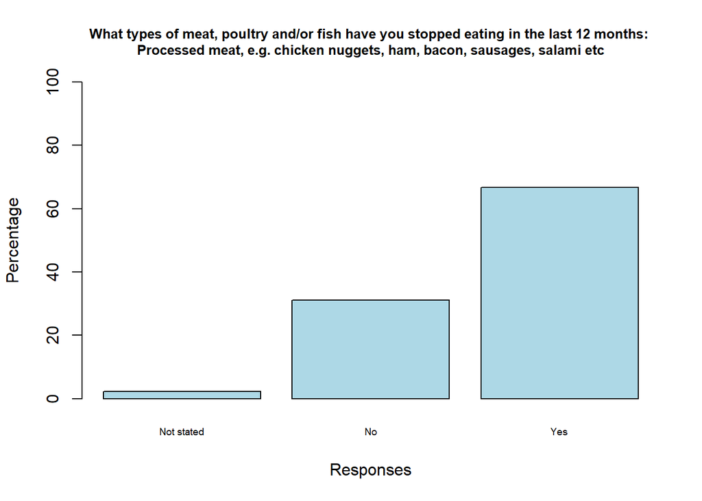

```r
barplot(table(yes_subsetQ48$stopmpf2)/length(yes_subsetQ48$stopmpf2) * 100,
        main = "What types of meat, poultry and/or fish have you stopped eating in the last 12 months: \nProcessed meat, e.g. chicken nuggets, ham, bacon, sausages, salami etc",
        xlab = "Responses",
        ylab = "Percentage",
        ylim = c(0, 100),
        names.arg = c("Not stated", "No", "Yes"),
        col = "lightblue",
        cex.main=0.8,
        cex.names=0.6)
```

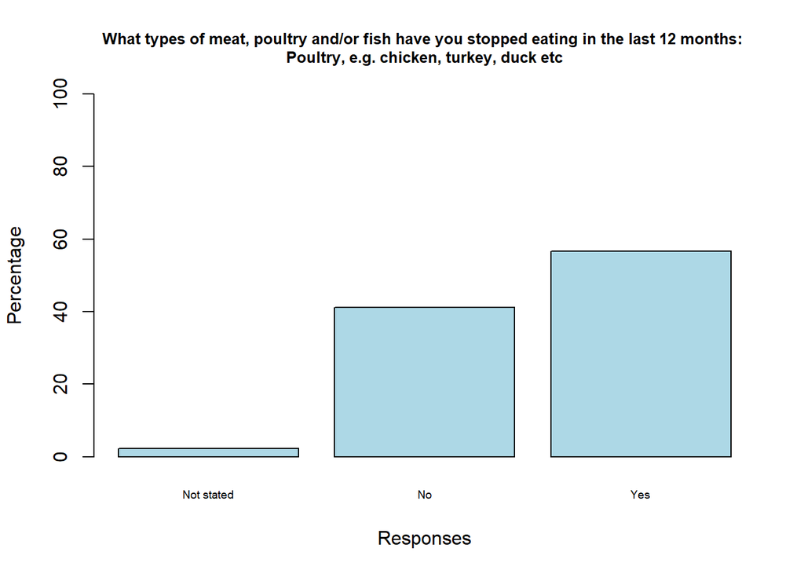

```r
barplot(table(yes_subsetQ48$stopmpf3)/length(yes_subsetQ48$stopmpf3) * 100,
        main = "What types of meat, poultry and/or fish have you stopped eating in the last 12 months: \nPoultry, e.g. chicken, turkey, duck etc",
        xlab = "Responses",
        ylab = "Percentage",
        ylim = c(0, 100),
        names.arg = c("Not stated", "No", "Yes"),
        col = "lightblue",
        cex.main=0.8,
        cex.names=0.6)
```

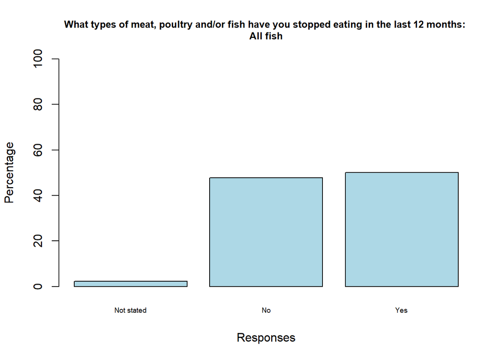

```r
barplot(table(yes_subsetQ48$stopmpf4)/length(yes_subsetQ48$stopmpf4) * 100,
        main = "What types of meat, poultry and/or fish have you stopped eating in the last 12 months: \nAll fish",
        xlab = "Responses",
        ylab = "Percentage",
        ylim = c(0, 100),
        names.arg = c("Not stated", "No", "Yes"),
        col = "lightblue",
        cex.main=0.8,
        cex.names=0.6)
```

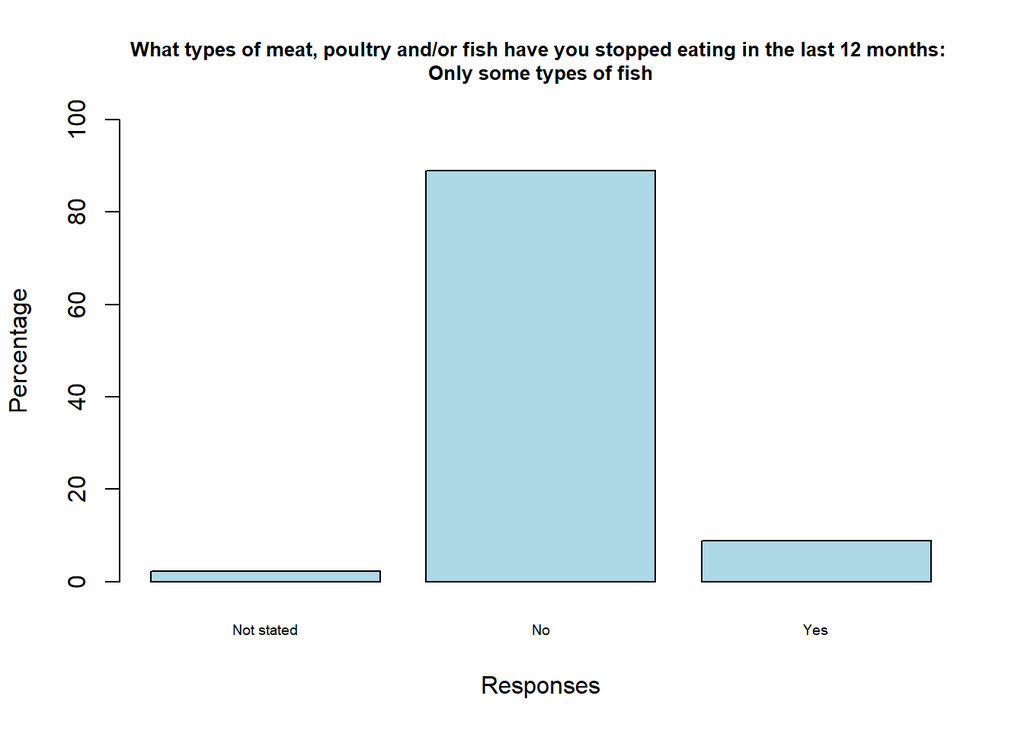

```r
barplot(table(yes_subsetQ48$stopmpf5)/length(yes_subsetQ48$stopmpf5) * 100,
        main = "What types of meat, poultry and/or fish have you stopped eating in the last 12 months: \nOnly some types of fish",
        xlab = "Responses",
        ylab = "Percentage",
        ylim = c(0, 100),
        names.arg = c("Not stated", "No", "Yes"),
        col = "lightblue",
        cex.main=0.8,
        cex.names=0.6)
```

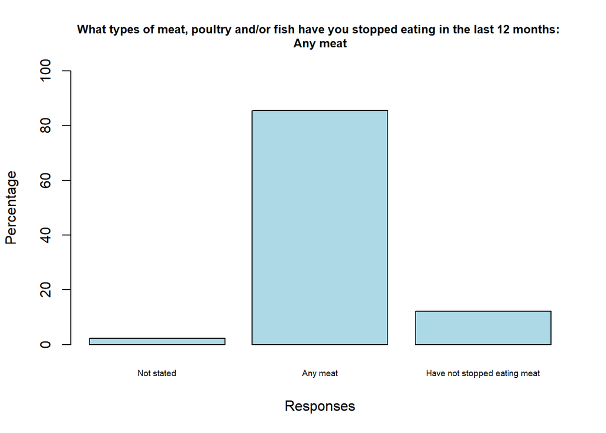

```r
barplot(table(yes_subsetQ48$stopmpf_net_1)/length(yes_subsetQ48$stopmpf_net_1) * 100,
        main = "What types of meat, poultry and/or fish have you stopped eating in the last 12 months: \nAny meat",
        xlab = "Responses",
        ylab = "Percentage",
        ylim = c(0, 100),
        names.arg = c("Not stated", "Any meat", "Have not stopped eating meat"),
        col = "lightblue",
        cex.main=0.8,
        cex.names=0.6)
```

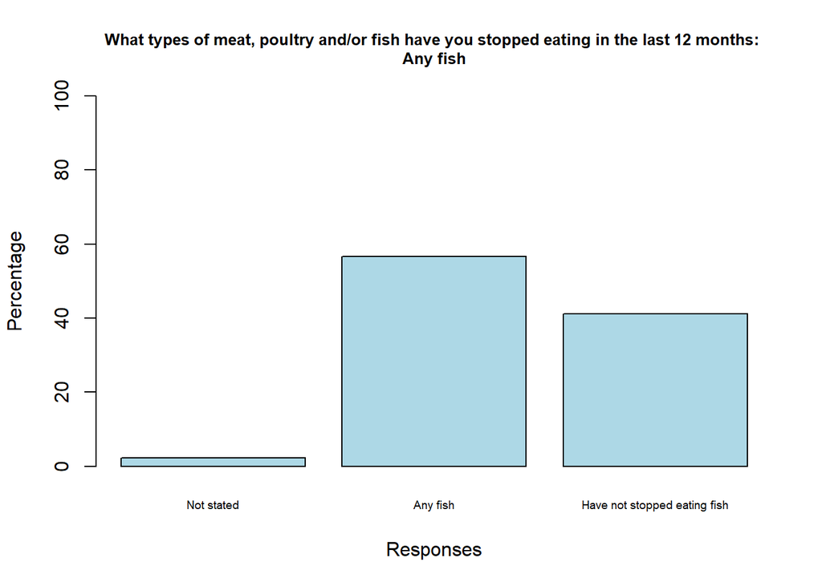

```r
barplot(table(yes_subsetQ48$stopmpf_net_2)/length(yes_subsetQ48$stopmpf_net_2) * 100,
        main = "What types of meat, poultry and/or fish have you stopped eating in the last 12 months: \nAny fish",
        xlab = "Responses",
        ylab = "Percentage",
        ylim = c(0, 100),
        names.arg = c("Not stated", "Any fish", "Have not stopped eating fish"),
        col = "lightblue",
        cex.main=0.8,
        cex.names=0.6)
```

## Why did you choose to stop eating red meat in the last 12 months

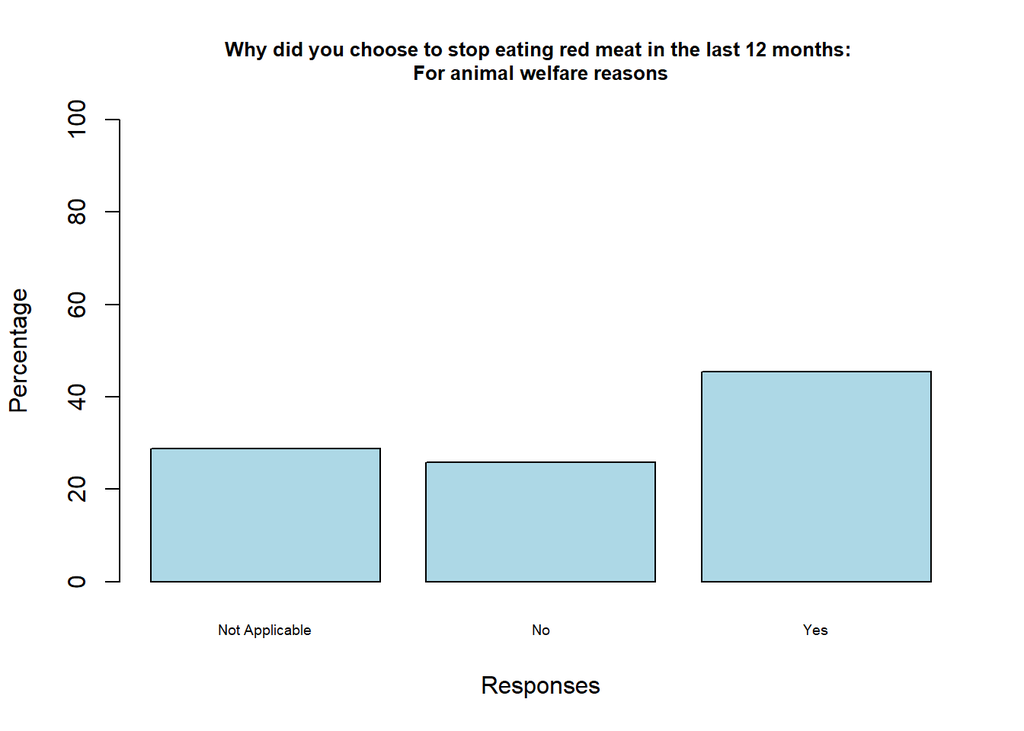

```r
yes_subset_redmeat <- subset(Wave_4, stopmpf1 == 1) #66obs

barplot(table(yes_subset_redmeat$whystopm1)/length(yes_subset_redmeat$whystopm1) * 100,
        main = "Why did you choose to stop eating red meat in the last 12 months: \nFor animal welfare reasons",
        xlab = "Responses",
        ylab = "Percentage",
        ylim = c(0, 100),
        names.arg = c("Not Applicable", "No", "Yes"),
        col = "lightblue",
        cex.main=0.8,
        cex.names=0.6)
```

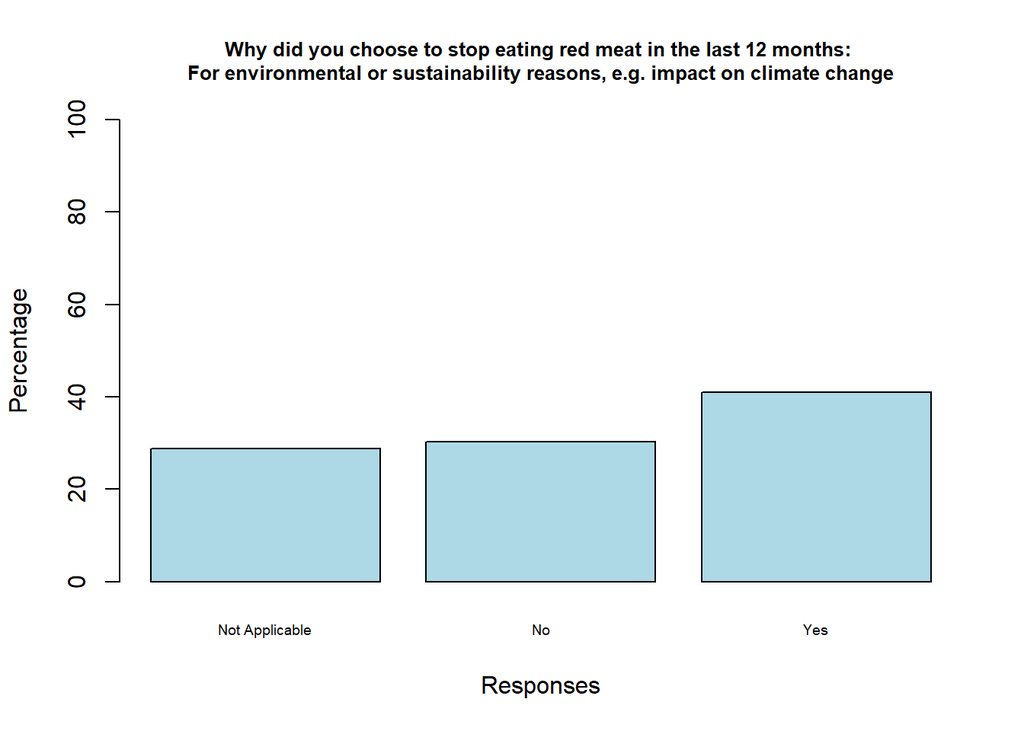

```r
barplot(table(yes_subset_redmeat$whystopm2)/length(yes_subset_redmeat$whystopm2) * 100,
        main = "Why did you choose to stop eating red meat in the last 12 months: \nFor environmental or sustainability reasons, e.g. impact on climate change",
        xlab = "Responses",
        ylab = "Percentage",
        ylim = c(0, 100),
        names.arg = c("Not Applicable", "No", "Yes"),
        col = "lightblue",
        cex.main=0.8,
        cex.names=0.6)
```

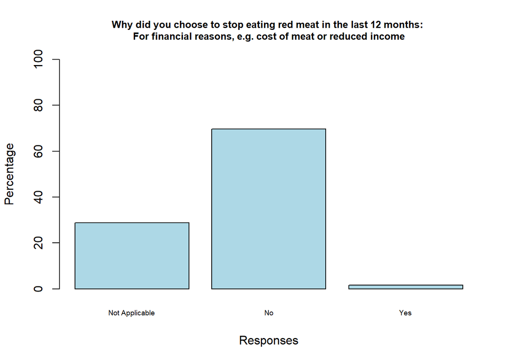

```r
barplot(table(yes_subset_redmeat$whystopm3)/length(yes_subset_redmeat$whystopm3) * 100,
        main = "Why did you choose to stop eating red meat in the last 12 months: \nFor financial reasons, e.g. cost of meat or reduced income",
        xlab = "Responses",
        ylab = "Percentage",
        ylim = c(0, 100),
        names.arg = c("Not Applicable", "No", "Yes"),
        col = "lightblue",
        cex.main=0.8,
        cex.names=0.6)
```

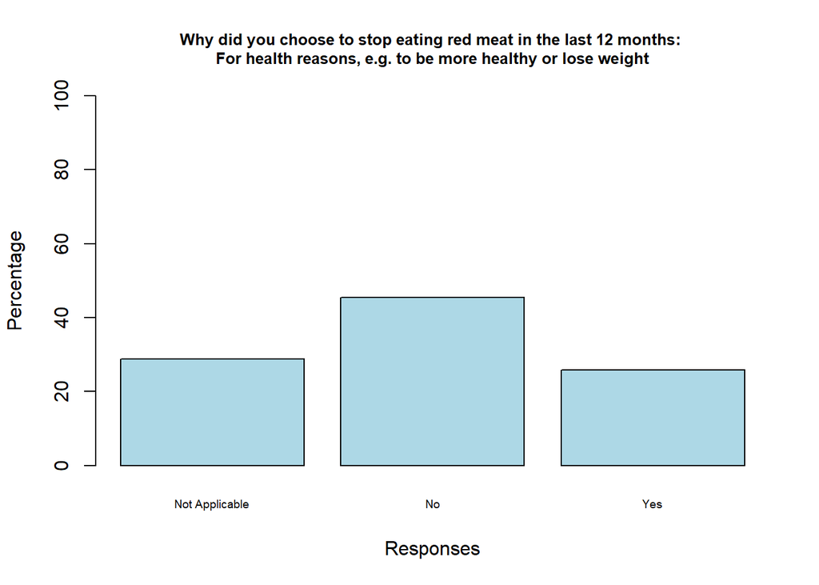

```r
barplot(table(yes_subset_redmeat$whystopm4)/length(yes_subset_redmeat$whystopm4) * 100,
        main = "Why did you choose to stop eating red meat in the last 12 months: \nFor health reasons, e.g. to be more healthy or lose weight",
        xlab = "Responses",
        ylab = "Percentage",
        ylim = c(0, 100),
        names.arg = c("Not Applicable", "No", "Yes"),
        col = "lightblue",
        cex.main=0.8,
        cex.names=0.6)
```

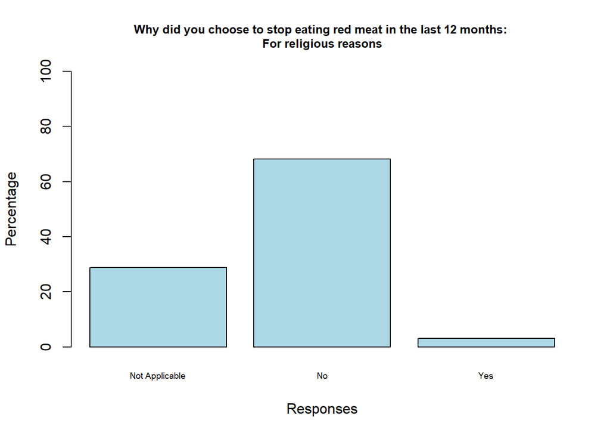

```r
barplot(table(yes_subset_redmeat$whystopm5)/length(yes_subset_redmeat$whystopm5) * 100,
        main = "Why did you choose to stop eating red meat in the last 12 months: \nFor religious reasons",
        xlab = "Responses",
        ylab = "Percentage",
        ylim = c(0, 100),
        names.arg = c("Not Applicable", "No", "Yes"),
        col = "lightblue",
        cex.main=0.8,
        cex.names=0.6)
```

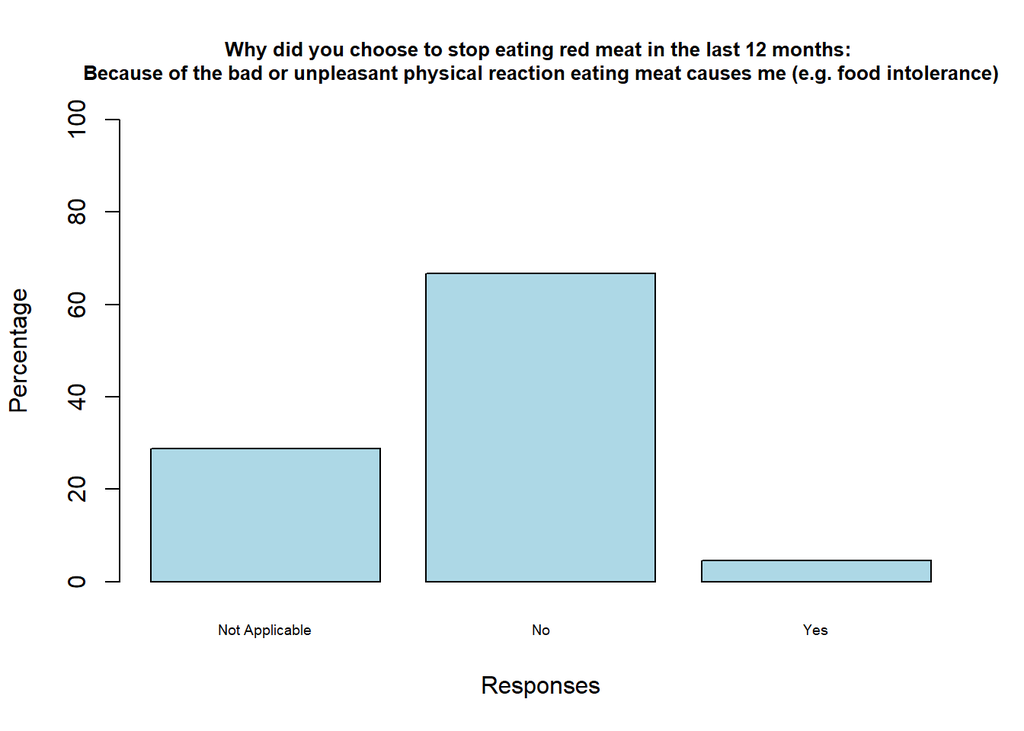

```r
barplot(table(yes_subset_redmeat$whystopm6)/length(yes_subset_redmeat$whystopm6) * 100,
        main = "Why did you choose to stop eating red meat in the last 12 months: \nBecause of the bad or unpleasant physical reaction eating meat causes me (e.g. food intolerance)",
        xlab = "Responses",
        ylab = "Percentage",
        ylim = c(0, 100),
        names.arg = c("Not Applicable", "No", "Yes"),
        col = "lightblue",
        cex.main=0.8,
        cex.names=0.6)
```

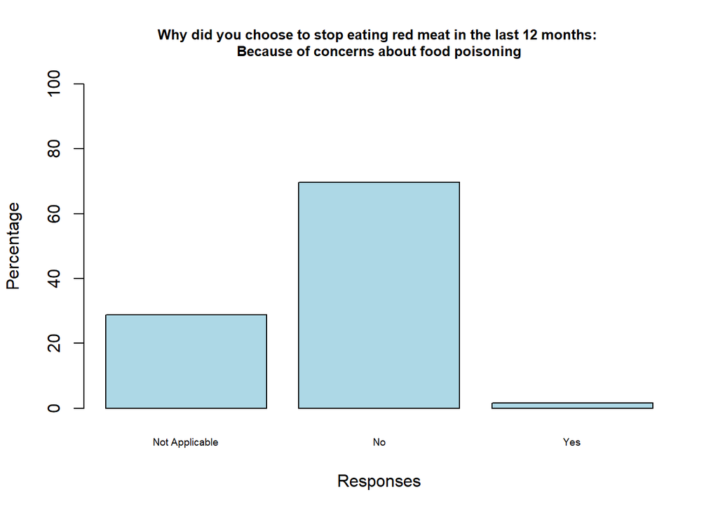

```r
barplot(table(yes_subset_redmeat$whystopm7)/length(yes_subset_redmeat$whystopm7) * 100,
        main = "Why did you choose to stop eating red meat in the last 12 months: \nBecause of concerns about food poisoning",
        xlab = "Responses",
        ylab = "Percentage",
        ylim = c(0, 100),
        names.arg = c("Not Applicable", "No", "Yes"),
        col = "lightblue",
        cex.main=0.8,
        cex.names=0.6)
```

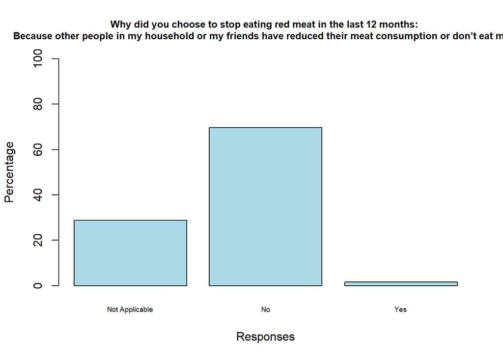

```r
barplot(table(yes_subset_redmeat$whystopm8)/length(yes_subset_redmeat$whystopm8) * 100,
        main = "Why did you choose to stop eating red meat in the last 12 months: \nBecause other people in my household or my friends have reduced their meat consumption or don’t eat meat",
        xlab = "Responses",
        ylab = "Percentage",
        ylim = c(0, 100),
        names.arg = c("Not Applicable", "No", "Yes"),
        col = "lightblue",
        cex.main=0.8,
        cex.names=0.6)
```

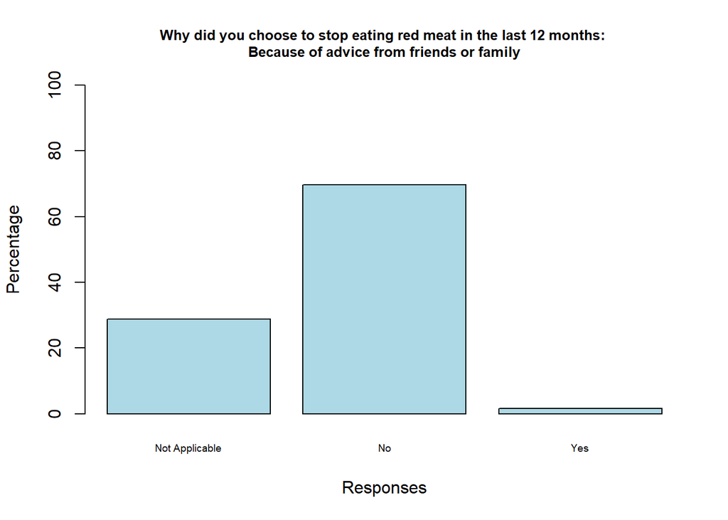

```r
barplot(table(yes_subset_redmeat$whystopm9)/length(yes_subset_redmeat$whystopm9) * 100,
        main = "Why did you choose to stop eating red meat in the last 12 months: \nBecause of advice from friends or family",
        xlab = "Responses",
        ylab = "Percentage",
        ylim = c(0, 100),
        names.arg = c("Not Applicable", "No", "Yes"),
        col = "lightblue",
        cex.main=0.8,
        cex.names=0.6)
```

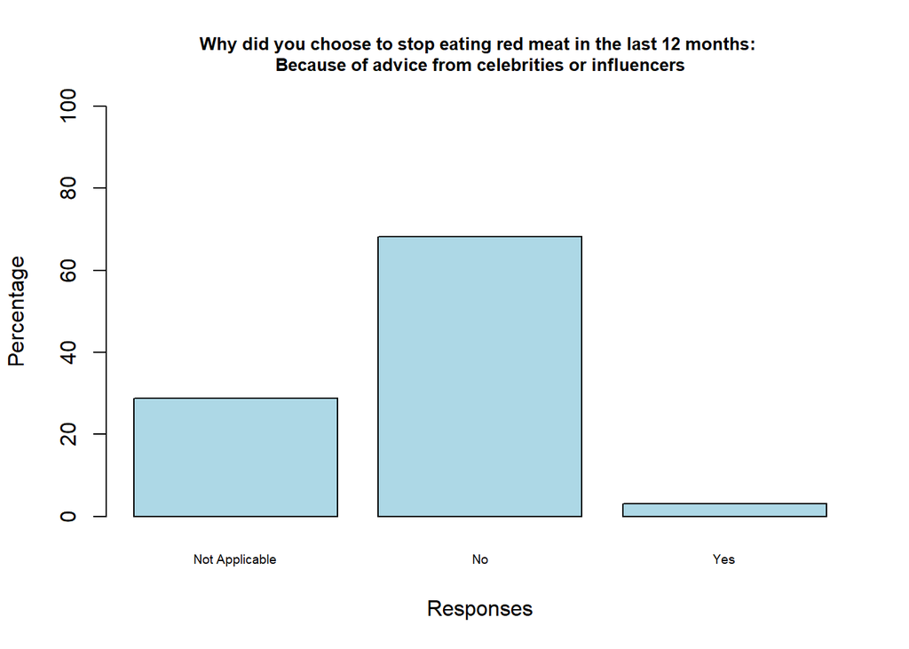

```r
barplot(table(yes_subset_redmeat$whystopm10)/length(yes_subset_redmeat$whystopm10) * 100,
        main = "Why did you choose to stop eating red meat in the last 12 months: \nBecause of advice from celebrities or influencers",
        xlab = "Responses",
        ylab = "Percentage",
        ylim = c(0, 100),
        names.arg = c("Not Applicable", "No", "Yes"),
        col = "lightblue",
        cex.main=0.8,
        cex.names=0.6)
```

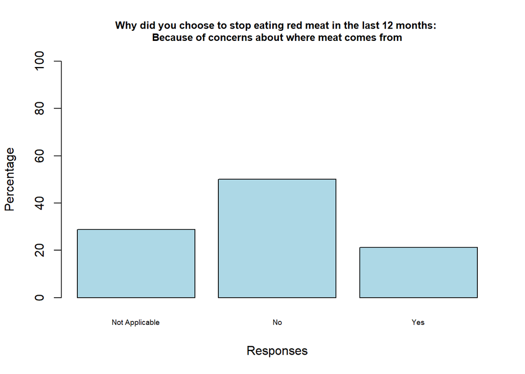

```r
barplot(table(yes_subset_redmeat$whystopm11)/length(yes_subset_redmeat$whystopm11) * 100,
        main = "Why did you choose to stop eating red meat in the last 12 months: \nBecause of concerns about where meat comes from",
        xlab = "Responses",
        ylab = "Percentage",
        ylim = c(0, 100),
        names.arg = c("Not Applicable", "No", "Yes"),
        col = "lightblue",
        cex.main=0.8,
        cex.names=0.6)
```

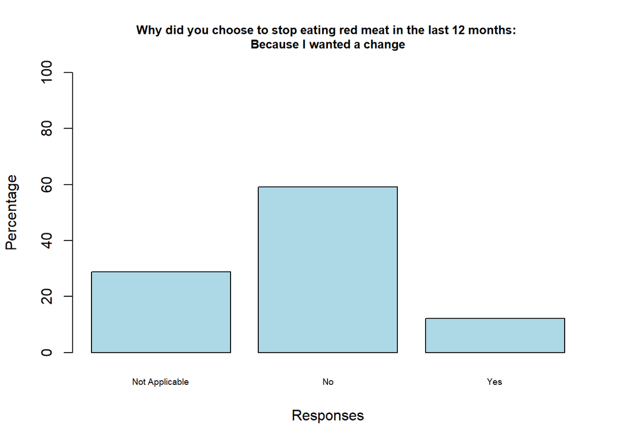

```r
barplot(table(yes_subset_redmeat$whystopm12)/length(yes_subset_redmeat$whystopm12) * 100,
        main = "Why did you choose to stop eating red meat in the last 12 months: \nBecause I wanted a change",
        xlab = "Responses",
        ylab = "Percentage",
        ylim = c(0, 100),
        names.arg = c("Not Applicable", "No", "Yes"),
        col = "lightblue",
        cex.main=0.8,
        cex.names=0.6)
```

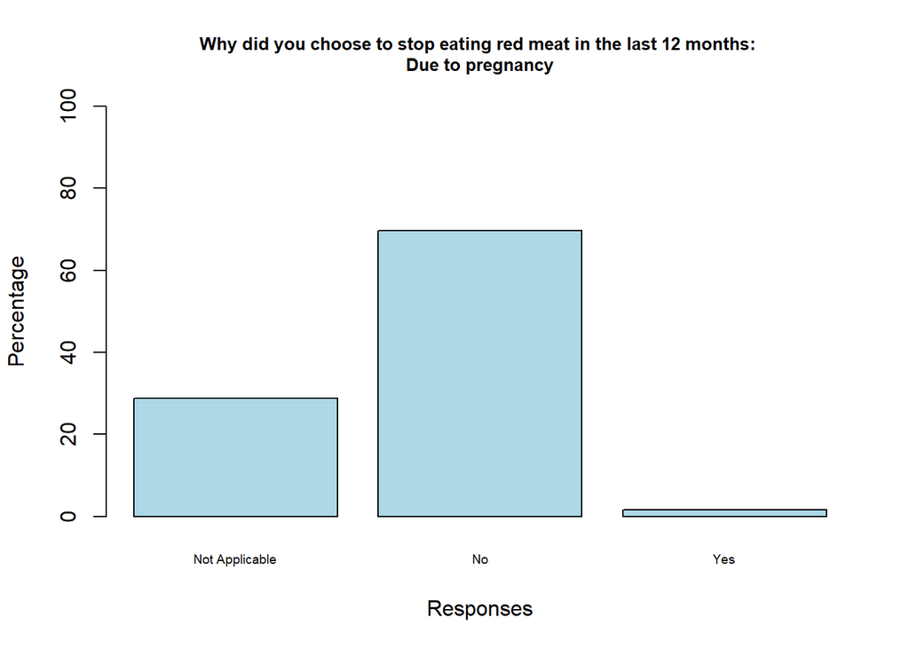

```r
barplot(table(yes_subset_redmeat$whystopm13)/length(yes_subset_redmeat$whystopm13) * 100,
        main = "Why did you choose to stop eating red meat in the last 12 months: \nDue to pregnancy",
        xlab = "Responses",
        ylab = "Percentage",
        ylim = c(0, 100),
        names.arg = c("Not Applicable", "No", "Yes"),
        col = "lightblue",
        cex.main=0.8,
        cex.names=0.6)
```

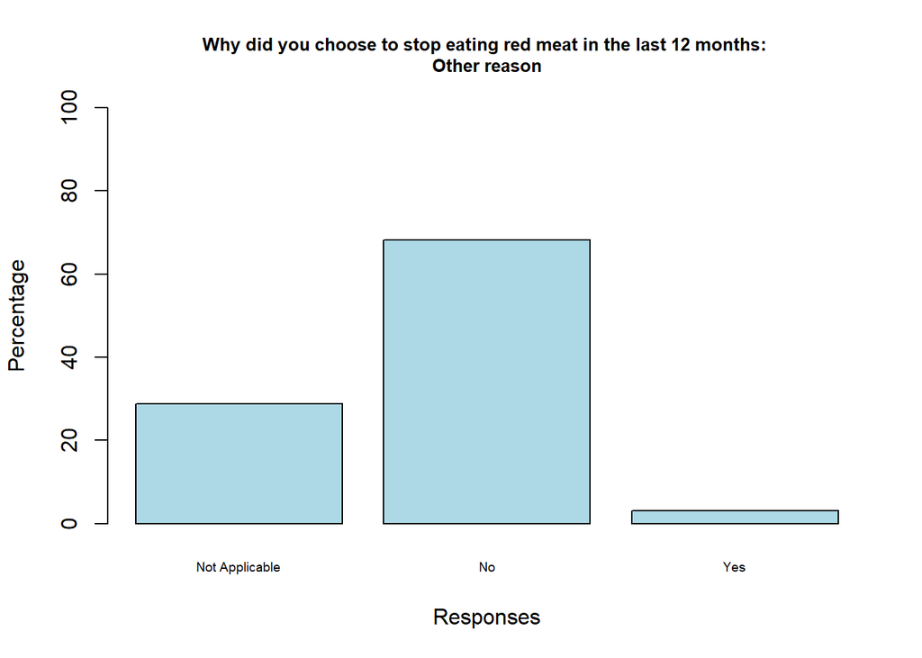

```r
barplot(table(yes_subset_redmeat$whystopm14)/length(yes_subset_redmeat$whystopm14) * 100,
        main = "Why did you choose to stop eating red meat in the last 12 months: \nOther reason",
        xlab = "Responses",
        ylab = "Percentage",
        ylim = c(0, 100),
        names.arg = c("Not Applicable", "No", "Yes"),
        col = "lightblue",
        cex.main=0.8,
        cex.names=0.6)
```

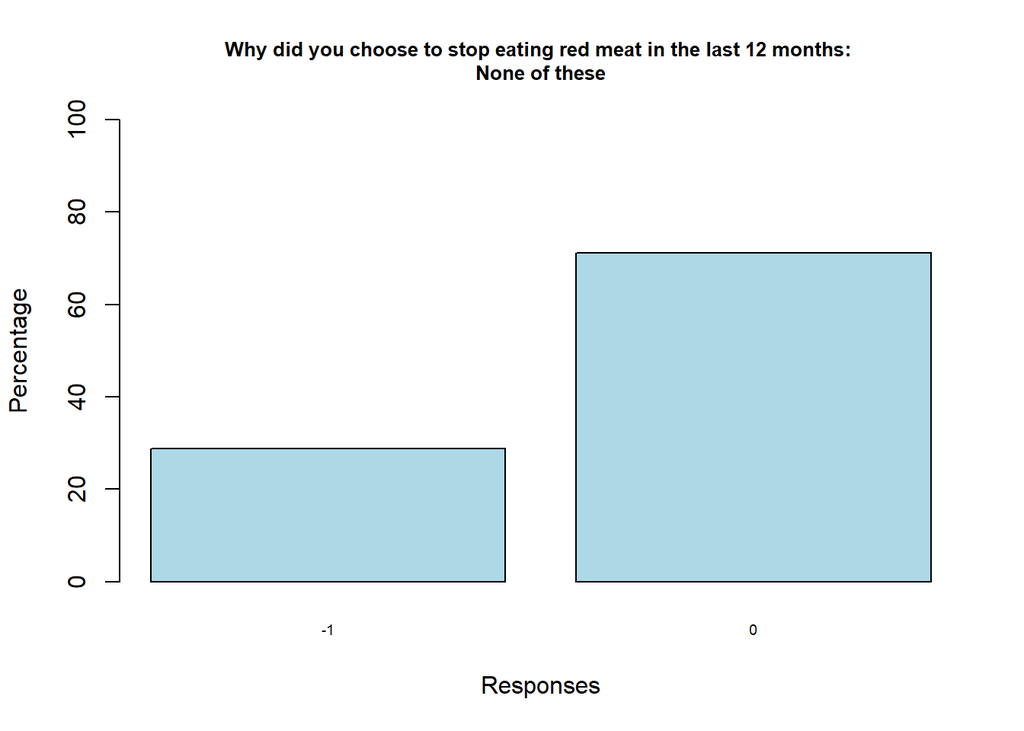

```r
barplot(table(yes_subset_redmeat$whystopm15)/length(yes_subset_redmeat$whystopm15) * 100,
        main = "Why did you choose to stop eating red meat in the last 12 months: \nNone of these",
        xlab = "Responses",
        ylab = "Percentage",
        ylim = c(0, 100),

        col = "lightblue",
        cex.main=0.8,
        cex.names=0.6)
```

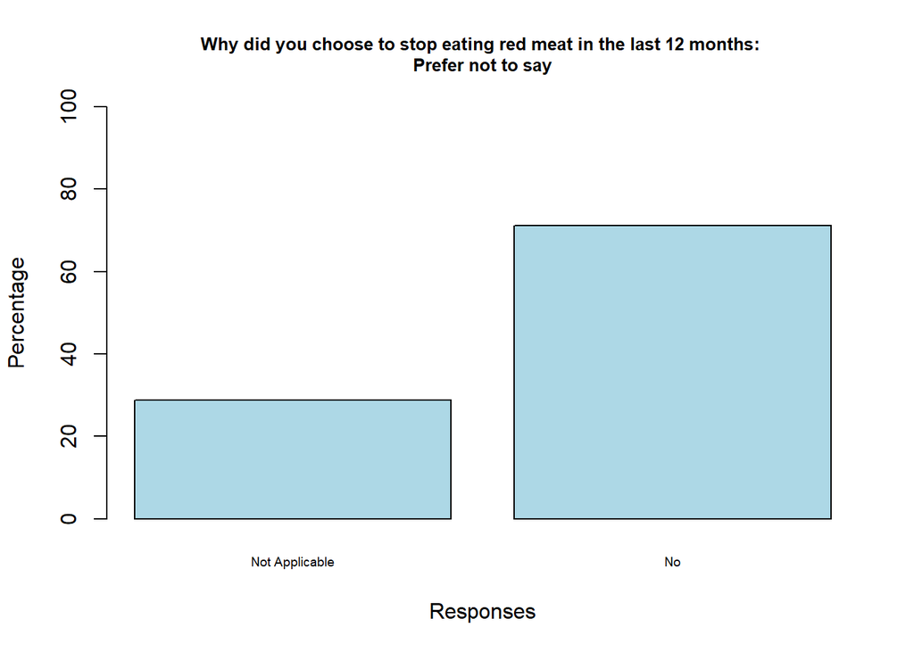

```r
barplot(table(yes_subset_redmeat$whystopm16)/length(yes_subset_redmeat$whystopm16) * 100,
        main = "Why did you choose to stop eating red meat in the last 12 months: \nPrefer not to say",
        xlab = "Responses",
        ylab = "Percentage",
        ylim = c(0, 100),
        names.arg = c("Not Applicable", "No"),
        col = "lightblue",
        cex.main=0.8,
        cex.names=0.6)
```

## Why did you choose to stop eating processed meat in the last 12 months

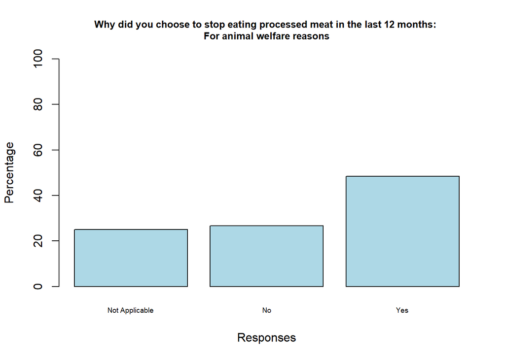

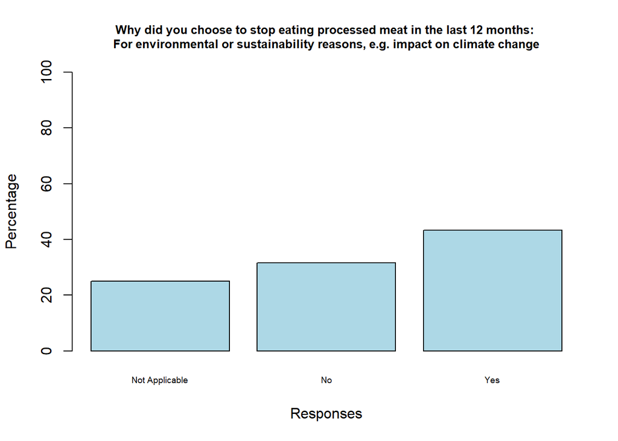

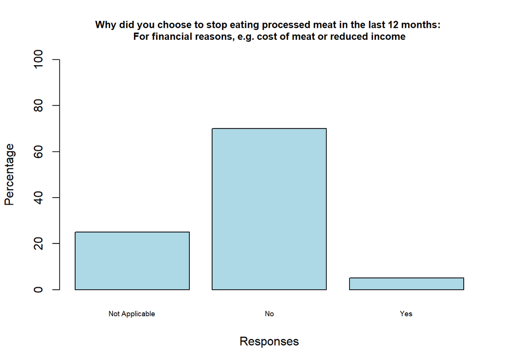

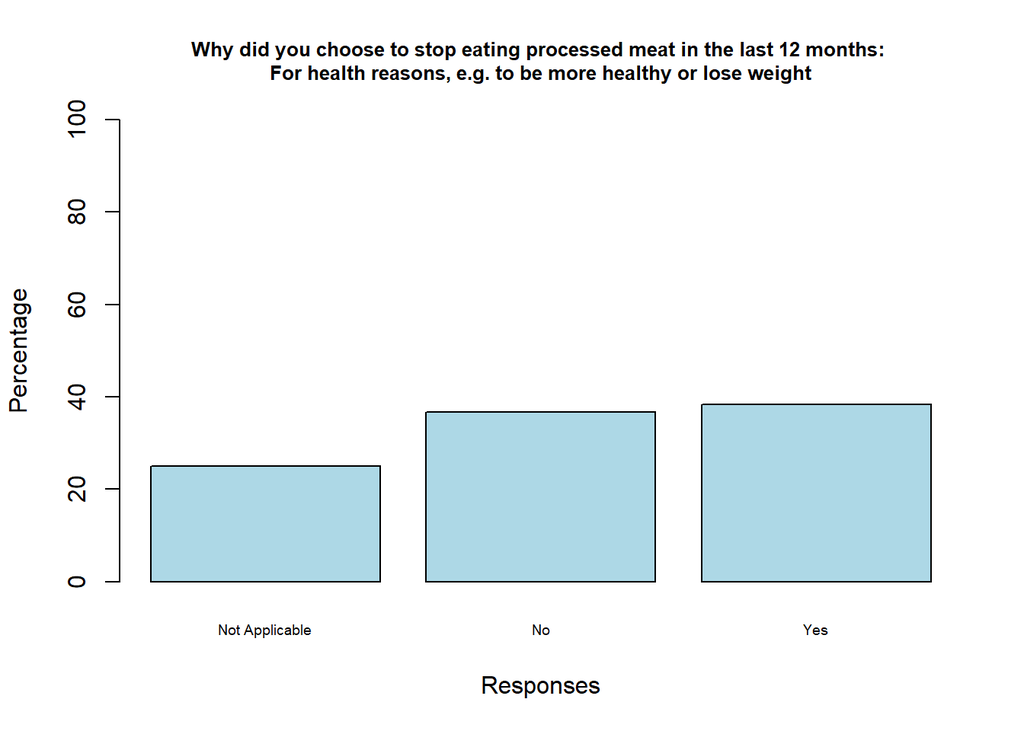

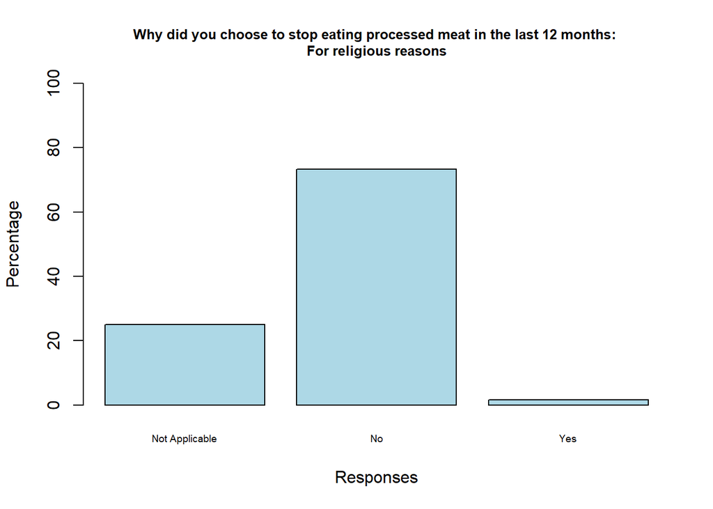

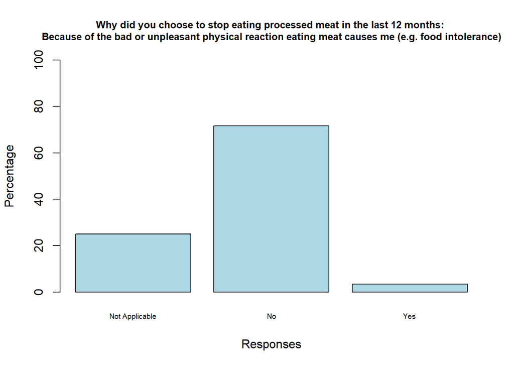

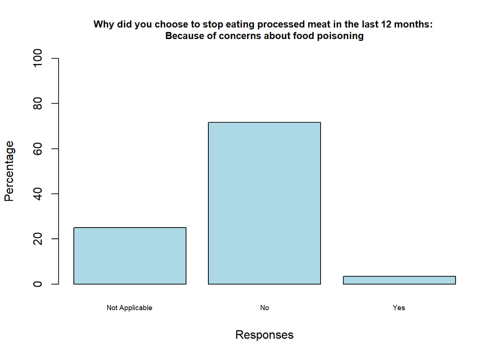

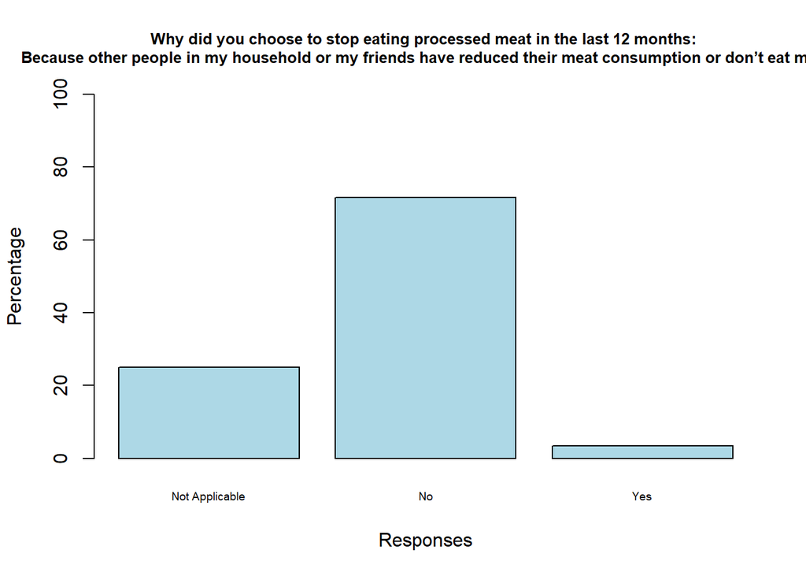

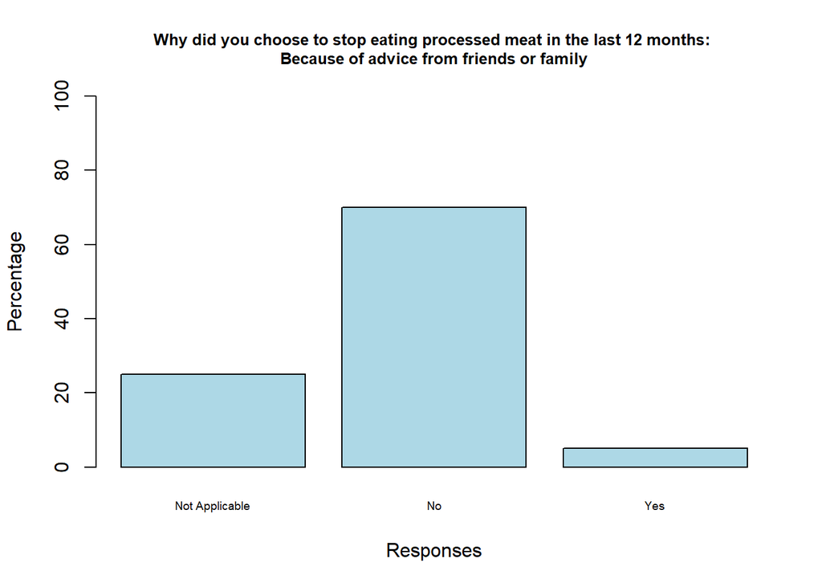

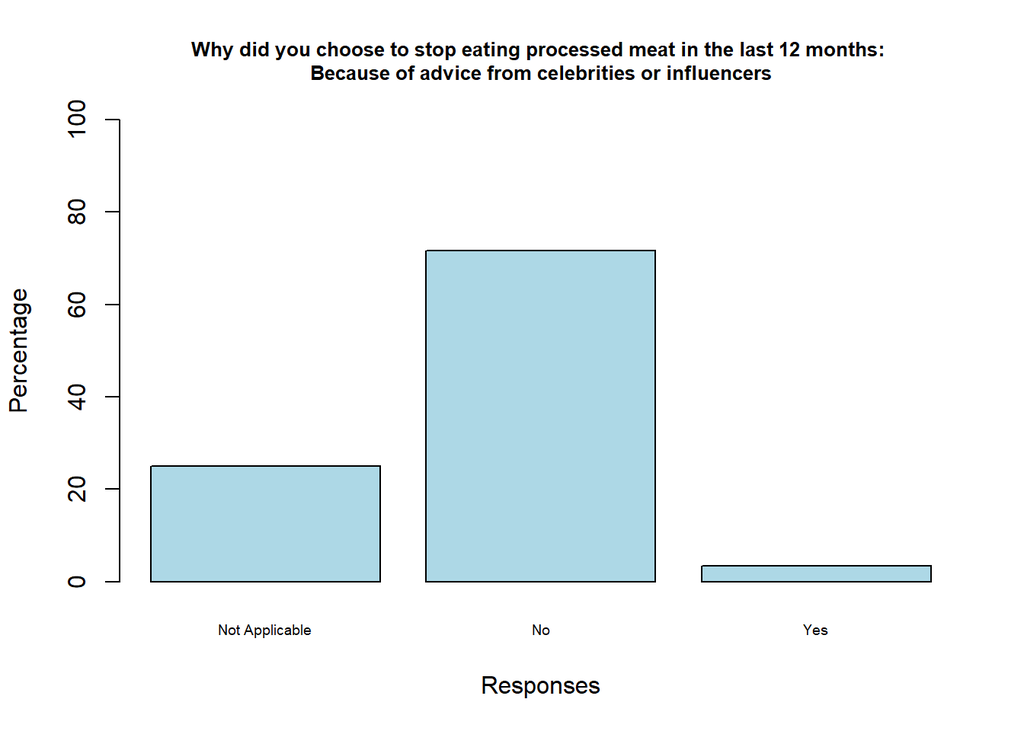

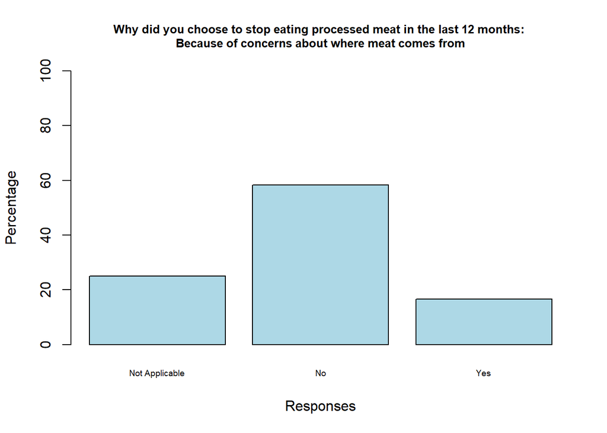

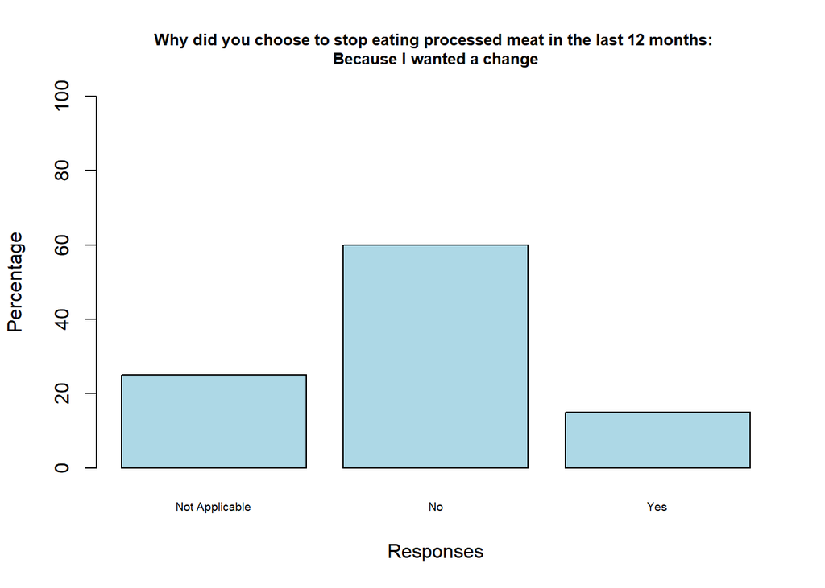

[4 more figures not shown]

## What types of meat, poultry and/or fish have you eaten less of in the last 12 months

```
## [1] 51
```

```
## [1] 45
```

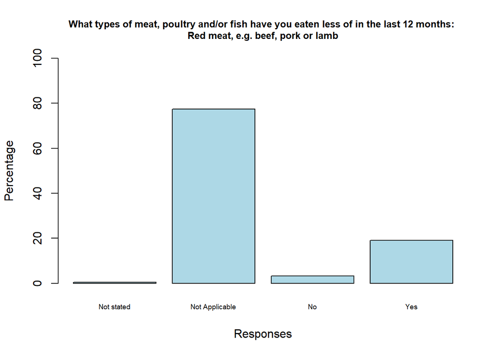

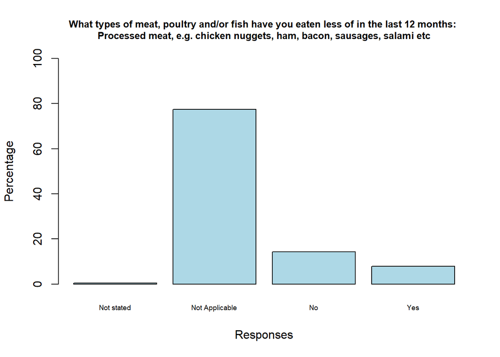

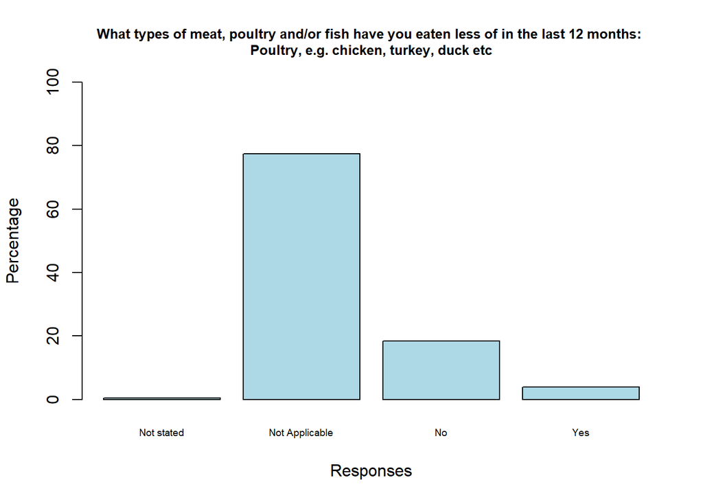

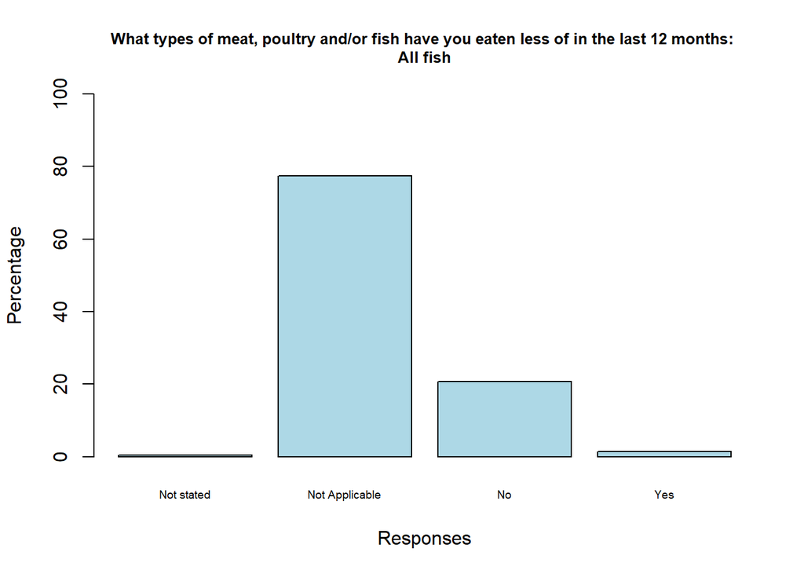

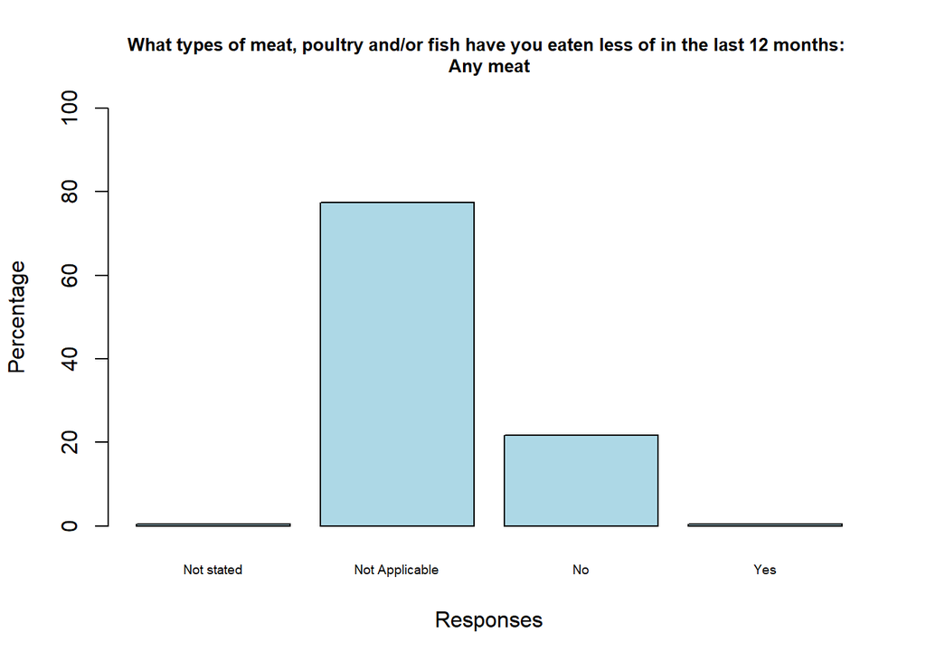

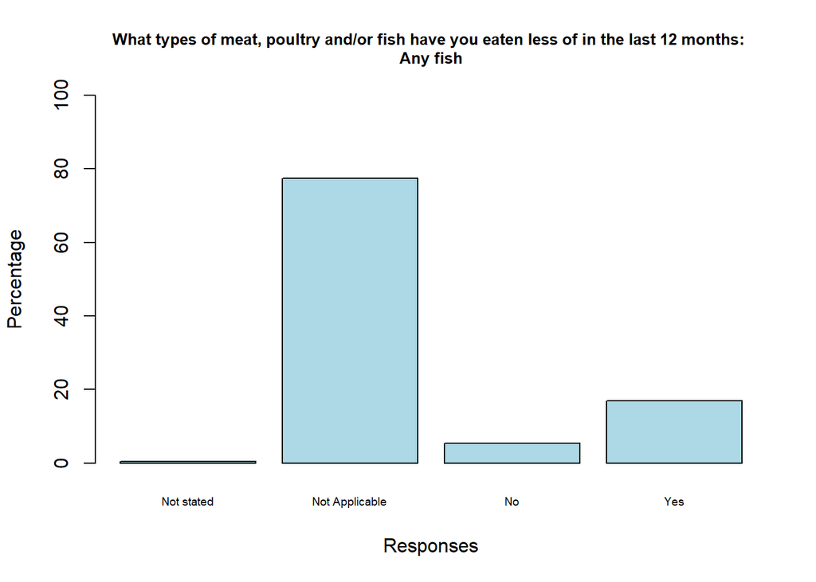

## Why did you choose to eat less red meat in the last 12 months

```
## [1] 1101
```

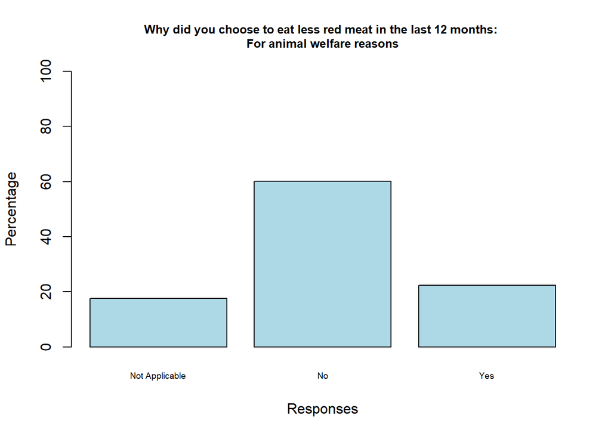

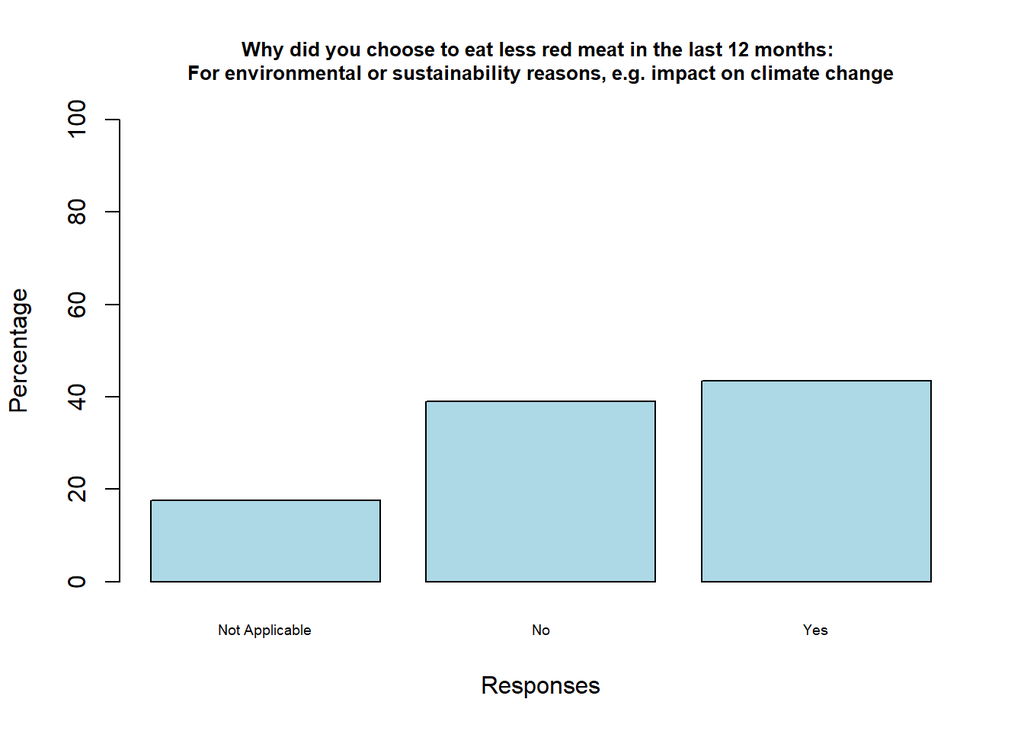

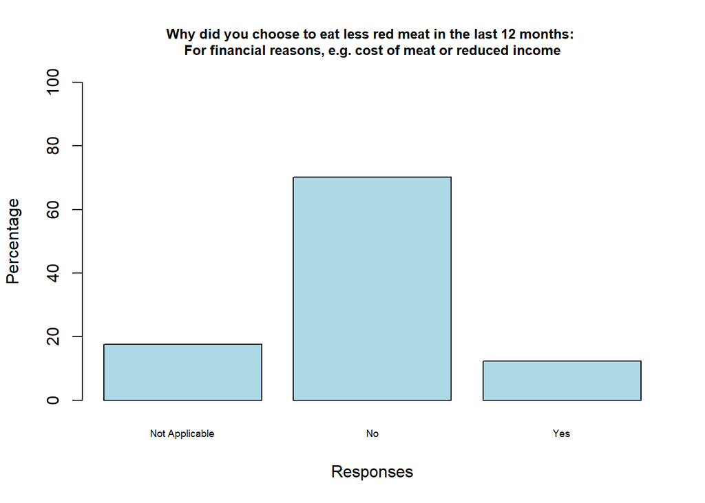

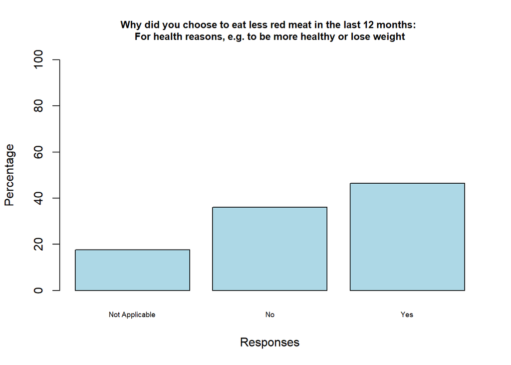

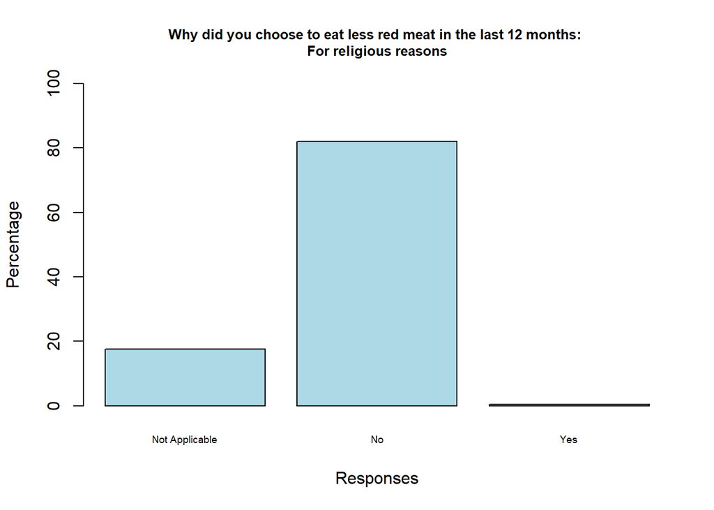

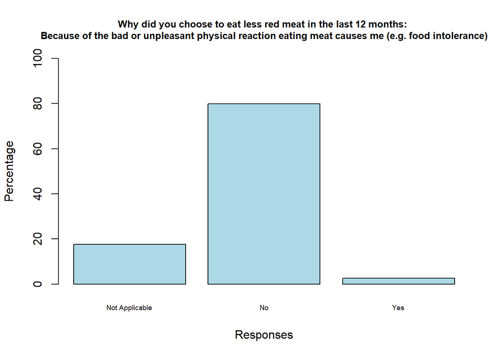

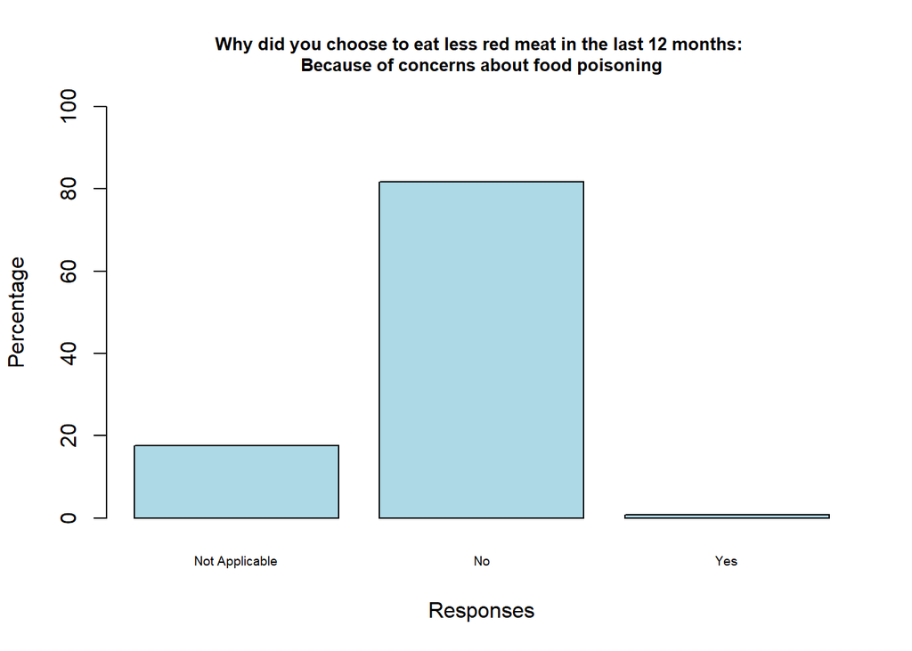

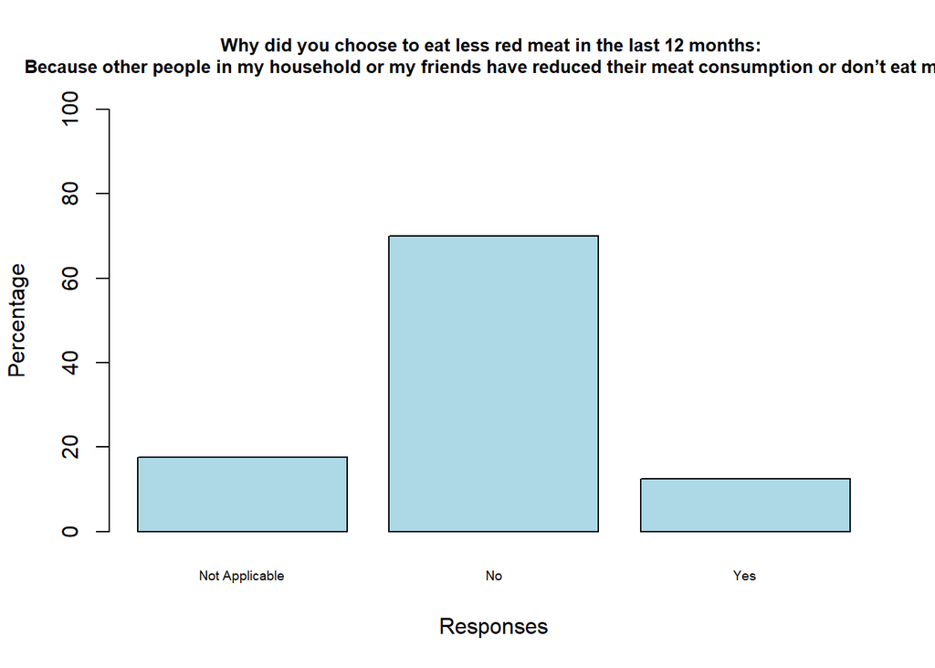